# Homework2

Yuqian Liu

08 February 2018

## Problem 1

**Answer:**

Cauchy$(\theta ,1)$ distribution has probability density $p(x;\theta ) = \frac{1}{{\pi [1 + {{(x - \theta )}^2}]}},$ where $x \in R$ and $\theta \in R$.

1. The likelihood function of $\theta$ is $L(x,\theta ) = \prod\limits_{i = 1}^n {p({x_i};\theta )}$. Then, the log-likelihood is
   $$\begin{align}
   \begin{array}{l}
   l(\theta ) = \sum\limits_{i = n}^n {\log (p({x_i};\theta ))} \\
   = \sum\limits_{i = n}^n
   {\log (\frac{1}{{\pi [1 + {{(x - \theta )}^2}]}})} \\
   = \sum\limits_{i = n}^n {[\log \frac{1}{\pi } +
   \log \frac{1}{{1 + {{(x - \theta )}^2}}}} ]\\
   = - n\ln \pi - \sum\limits_{i
   = n}^n {\ln [1 + {{(\theta - {x_i})}^2}]}
   \end{array}
   \end{align}$$
   Thus, $l'(\theta)$ and $l''(\theta)$ are,
   $$\begin{align}
   \begin{array}{l}
   l'(\theta ) = - \sum\limits_{i = n}^n {\frac{{p'({x_i};\theta )}}{{p({x_i};\theta )}}} \\
   = - \sum\limits_{i = n}^n {[\frac{1}{{1 +
   {{(\theta - {x_i})}^2}}} \times 2(\theta - {x_i})]} \\
   = - 2\sum\limits_{i = n}^n {\frac{{\theta - {x_i}}}
   {{1 + {{(\theta - {x_i})}^2}}}}
   \end{array}
   \end{align}$$

$$\begin{align}
\begin{array}{l}
l''(\theta ) = \sum\limits_{i = n}^n {\frac{p''(x_i;\theta )}{p(x_i;\theta )}}
- \sum\limits_{i = n}^n {\{ \frac{p'(x_i;\theta )}{p(x_i;\theta )}} {\} ^2}\\
= - 2\sum\limits_{i = n}^n {\frac{1 - (\theta - x_i)^2}{[1 + (\theta - x_i)^2]^2}}
\end{array}
\end{align}$$

The fisher information is
$$\begin{align}
\begin{array}{l}
I(\theta ) = - {{\rm E}_\theta }\{ l''(\theta )\} \\
= - n{{\rm E}_\theta }[\frac{p''(x_i;\theta )}{p(x_i;\theta )} -
{\{ \frac{p'(x_i;\theta )}{p(x_i;\theta )}\} ^2}]\\
= - n\int {[\frac{p''(x_i;\theta )}{p(x_i;\theta )} -
{{\{ \frac{p'(x_i;\theta )}{p(x_i;\theta )}\} }^2}]p(x_i;\theta )dx} \\
= - n\int {\frac{{\{ p'(x)\} }^2}{p(x)}dx} \\
= \frac{4n}{\pi }\int_{ - \infty }^\infty {\frac{{{x^2}dx}}{{(1 + x^2)}^3}} \\
= \frac{n}{2}
\end{array}
\end{align}$$

2. The observed sample is

```r
x1 <- c(1.77, -0.23, 2.76, 3.80, 3.47, 56.75, -1.34, 4.24, -2.44,
       3.29, 3.71, -2.40, 4.53, -0.07, -1.05, -13.87, -2.53, -1.75)
```

The log-likelihood function is shown in following figure.

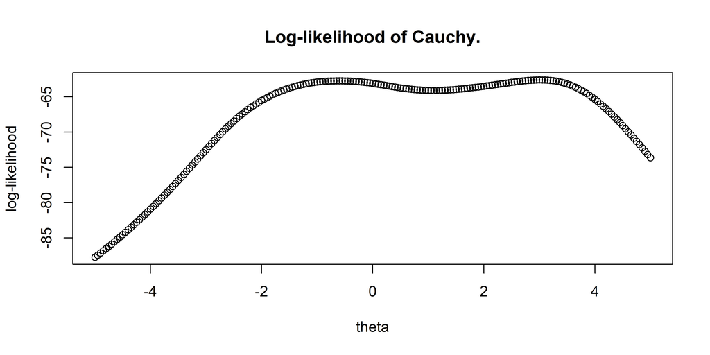

```r
plot(Theta_value, LogLik_plot,xlab = "theta",ylab = "log-likelihood",
     main = "Log-likelihood of Cauchy.")
```

Then, Newton-Raphson method with

```r
StartPoints <- c(-11, -1, 0, 1.5, 4, 4.7, 7, 8, 38)
```

and sample mean as start points have been applied. The results are shown in follow.

```r
knitr::kable(mytab1.b, caption = 'Newton-Raphson Method Results', booktabs = TRUE)
```

Newton-Raphson Method Results

|  | theta1.b | itel1.b |
| --- | --- | --- |
| par | -0.5914762 | 8 |
| par | -0.5914735 | 4 |
| par | -0.591474 | 5 |
| par | 3.021345 | 8 |
| par | 3.021345 | 5 |
| par | 3.021346 | 7 |
| par | 3.021346 | 4 |
| par | -0.5914708 | 7 |
| par | -0.5914735 | 11 |
| par | 3.021343 | 5 |

3. The fixed-point iterations using $G(x)=\alpha l'(\theta)+\theta$ with scaling choices of $\alpha \in \{1, 0.64, 0.25\}$ is applied as follow,

```r
# l'(\theta)
logLik_1st <- function(theta, x = x1){
  n <- length(x)
  term <- 0
  for(i in 1:n){
    term <- term + (theta-x1[i])/(1+(theta-x[i])^2)
  }
  -2*term
}
# G = alpha*l'(\theta)+theta
G <- function(theta, alpha, x = x1){
  alpha*logLik_1st(theta, x = x1) + theta
}

myIterator <- function(theta_init, f, eps = 1e-06, itmax = 10000, verbose = FALSE,
                       ...) {
  theta_old <- theta_init
  itel <- 1
  repeat {
    # theta_t+1 = G
    theta_new <- f(theta_old, ...)
    if (verbose)
      cat("Iteration: ", formatC(itel, width = 3, format = "d"), "theta_old: ",
          formatC(theta_old, digits = 8, width = 12, format = "f"), "theta_new: ",
          formatC(theta_new, digits = 8, width = 12, format = "f"), "\n")
    if ((abs(theta_old - theta_new) < eps) || (itel == itmax)) {
      return(c(theta_new, itel))
    }
    theta_old <- theta_new
    itel <- itel + 1
  }
}
```

The results are shown as follow,.1, .2 and .3 represents results with 3 different $\alpha$ values.

```r
alphas <- c(1, 0.64, 0.25)
```

Fixed Point Method Results

| theta.1 | theta.2 | theta.3 | iteration.1 | iteration.2 | iteration.3 |
| --- | --- | --- | --- | --- | --- |
| -0.5914740 | -0.5914734 | -0.5914745 | 218 | 17 | 28 |
| -1.1713919 | -0.5914734 | -0.5914741 | 1000 | 11 | 20 |
| 0.1035079 | -0.5914736 | -0.5914726 | 1000 | 11 | 20 |
| -1.1713919 | 2.5915177 | 3.0213454 | 1000 | 1000 | 12 |
| 0.1035079 | -0.5914736 | 3.0213454 | 1000 | 12 | 8 |
| 0.2417269 | -0.5914736 | 3.0213454 | 1000 | 13 | 9 |
| 0.2417269 | 3.2398379 | 3.0213454 | 1000 | 1000 | 8 |
| -1.1063091 | -0.5914736 | 3.0213454 | 1000 | 14 | 10 |
| -1.1063091 | 3.2398379 | 3.0213454 | 1000 | 1000 | 93 |

4. The fisher scoring refined by Newton method has been conducted. The results are shown as follow.

Fisher Scoring Method Results

| theta | iteration |
| --- | --- |
| -0.5914768 | 71 |
| -0.5914768 | 48 |
| -0.5914705 | 50 |
| 3.0213444 | 35 |
| 3.0213464 | 23 |
| 3.0213463 | 24 |
| 3.0213468 | 26 |
| 3.0213465 | 28 |
| 3.0213468 | 216 |

```r
knitr::kable(mytab1.d.withNewton, caption = 'Refined with Newton', booktabs = TRUE)
```

Refined with Newton

| par | -0.5914768 | -0.5914768 | -0.5914762 | 3.021344 | 3.021346 | 3.021346 | 3.021347 | 3.021347 | 3.021347 |
| --- | --- | --- | --- | --- | --- | --- | --- | --- | --- |
| objective | 62.73186 | 62.73186 | 62.73186 | 62.59032 | 62.59032 | 62.59032 | 62.59032 | 62.59032 | 62.59032 |
| convergence | 0 | 0 | 0 | 0 | 0 | 0 | 0 | 0 | 0 |
| iterations | 1 | 1 | 1 | 1 | 1 | 1 | 1 | 1 | 1 |
| evaluations | 2, 1 | 2, 1 | 2, 3 | 2, 1 | 2, 1 | 2, 1 | 2, 1 | 2, 1 | 2, 1 |
| message | relative convergence (4) | relative convergence (4) | relative convergence (4) | relative convergence (4) | relative convergence (4) | relative convergence (4) | relative convergence (4) | relative convergence (4) | relative convergence (4) |

5. Compare the results from these different methods, we could see Newton-Raphson method takes general less iterations compared with other methods. For fixed point method, the choice of $\alpha$ is crucial. We see it may not converge to the optimal when $\alpha = 1$. However, if we choose a good $\alpha$, the performance are good. Fisher Scoring has stable perfomance but with time consuming. Then refined by Newton method, it get results very fast.

## Problem 2

**Answer:**

The probability density with parameter $\theta$ is $p(x;\theta ){\rm{ }} = {\rm{ }}\frac{{1 - cos(x - \theta )}}{{2\pi }}$, where $0 \le x \le 2\pi$ and $\theta \in ( - \pi ,{\rm{ }}\pi )$.

1. The log-likelihood function of $\theta$ is
   $$\begin{align}
   \begin{array}{l}
   l(\theta ) = \sum\limits_{i = n}^n {\log (p({x_i};\theta ))} \\
   = - 2n\ln \pi + \sum\limits_{i = n}^n {\ln [1 - cos(x - \theta )]}
   \end{array}
   \end{align}$$
   The observed sample is

```r
x2 <- c(3.91, 4.85, 2.28, 4.06, 3.70, 4.04, 5.46, 3.53, 2.28, 1.96,
       2.53, 3.88, 2.22, 3.47, 4.82, 2.46, 2.99, 2.54, 0.52)
```

The log-likelihood function is shown in Figure.

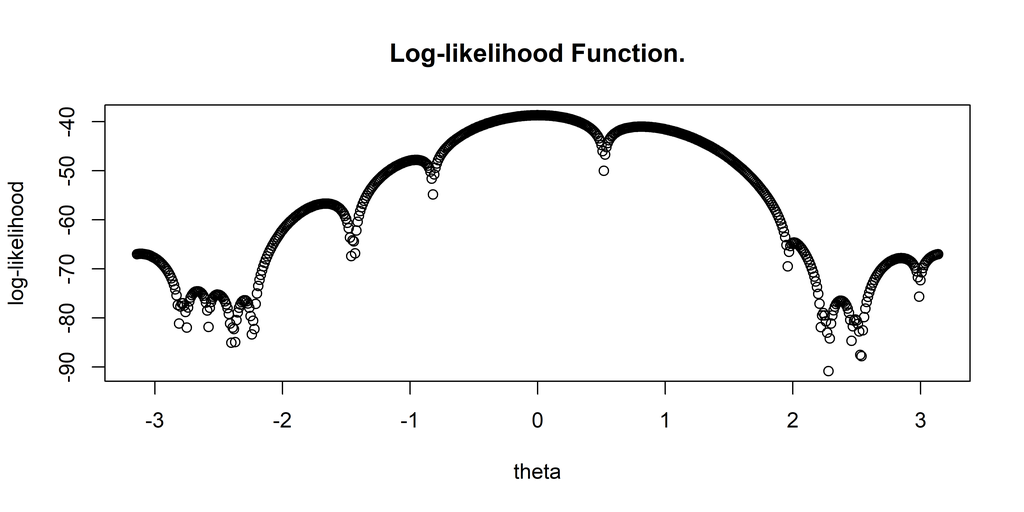

2. Method of moments
   $$\begin{align}
   \begin{array}{l}
   {\rm E}(X|\theta ) = \int_0^{2\pi } {p(x;\theta )} xdx\\
   = -\frac{1}{2\pi }[\cos (x - \theta ) - \frac{x^2}{2} + x\sin (x - \theta )]|_0^{2\pi }\\
   = \pi + \sin \theta
   \end{array}
   \end{align}$$
   Thus, ${\hat \theta _{moment}}$ could be calculated based on ${\rm E}(X|\theta ) = \bar x$. Solve for $\theta$,
   $$\begin{align}
   ${\hat \theta _{moment}} = \arcsin (\bar x - \pi )$
   \end{align}$$
3. With $\theta_0 = \hat \theta _{moment}$, using the Newton-Raphson method the MLE is

```
## Iteration:    4 ,theta:    0.00311816 ,objective:   38.67500474
```

4. With $\theta_0 = -2.7$ and $\theta_0 = 2.7$, the results are

With different start points

| par | -1.662712 | 2.848415 |
| --- | --- | --- |
| objective | 56.68446 | 67.80782 |
| convergence | 0 | 0 |
| iterations | 6 | 5 |
| evaluations | 8, 9 | 7, 7 |
| message | relative convergence (4) | relative convergence (4) |

5. Repeat the above using 200 equally spaced starting values between $-\pi$ and $\pi$. The results are too large to present here. It is seperated by sets of attraction.

```r
StartPoints3 <- seq(-pi,pi,length.out = 200)
results_e <- sapply(StartPoints3, function(x0) nlminb(x0,ObjectFun2))
```

## Problem 3

**Answer:**

The model for population growth is given by $\frac{{dN}}{{dt}} = rN(1 - \frac{N}{K})$. The solution of this is ${N_t} = f(t){\rm{ }} = \frac{{K{N_0}}}{{{N_0} + (K - {N_0}){\rm{ }}exp( - rt)}}$

1. By using nls() in R, the results are K = 1049.4074581, r = 0.1182683 at optimal.

Code chunk:

```r
beetles <- data.frame(
  days = c(0, 8, 28, 41, 63, 69, 97, 117, 135, 154),
  beetles = c(2, 47, 192, 256, 768, 896, 1120, 896, 1184, 1024))
tt <-  c(8, 28, 41, 63, 69, 97, 117, 135, 154)
N <- c(47, 192, 256, 768, 896, 1120, 896, 1184, 1024)
N0 <- 2

## lodaing package
library(ggplot2)

## Problem 3.a Gauss-Newton approach
#nls from R
mytab3 <- nls(N ~ K*N0/(N0+(K-N0)*exp(-r*tt)),
              start = list(K = 2000, r = 0.1), trace = TRUE)
```

2. The contour plots of the sum of squared errors are shown as follow,

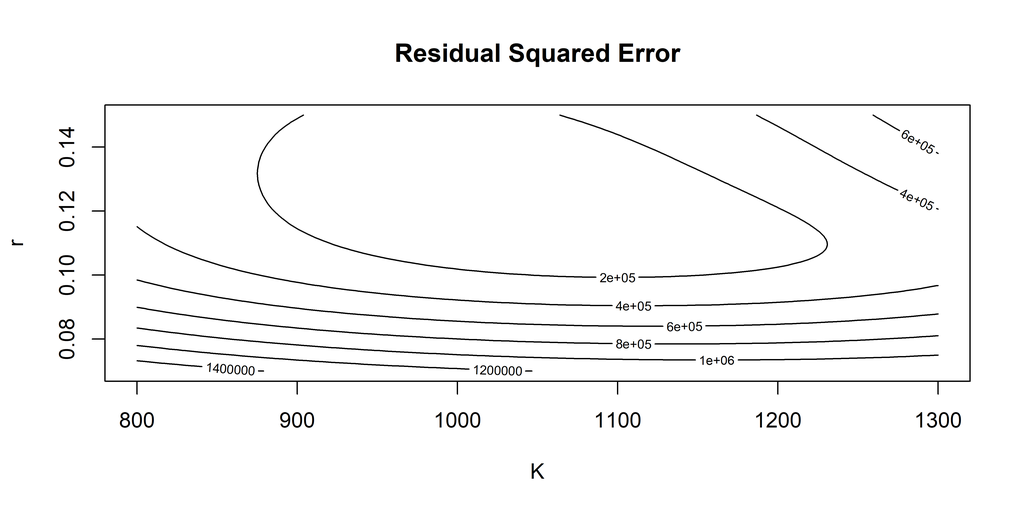

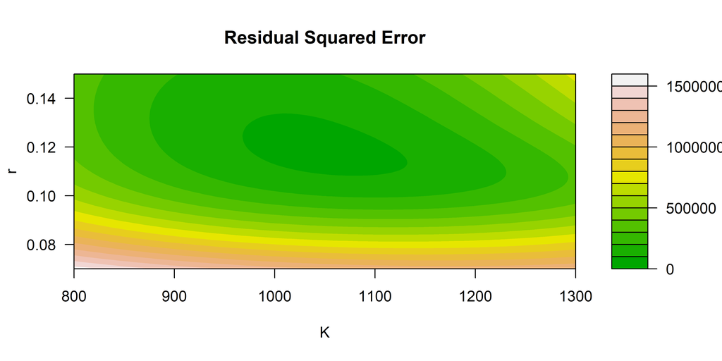

Code chunk:

```r
## Problem 3.b Countour residual error
#opti: K = 1049.4074581 r = 0.1182683
#range: K from 800 to 1300, r from 0.07 to 0.15
K_plot <- seq(800, 1300, length.out = 100)
r_plot <- seq(0.07, 0.15, length.out = 100)
residual <- rep(0, length(N))
error <- matrix(data = NA, nrow = length(K_plot), ncol = length(r_plot))
residual_error <- function(K, r){
  for (i in 1:length(N)) {
    residual[i] <- (N[i] - (K*N0)/(N0+(K-N0)*exp(-r*tt[i])))^2
  }
  sum(residual)
}
for (i in 1:100) {
  for (j in 1:100) {
    error[j,i] <- residual_error(K_plot[j],r_plot[i])
  }
}

contour(K_plot,r_plot,error, xlab="K", ylab="r",
               main="Residual Squared Error")
filled.contour(K_plot,r_plot,error,color.palette = terrain.colors,
               xlab="K", ylab="r",
               main="Residual Squared Error")
```